# assignment week 07

Iryna-ENElab

2026-04-24

Questions for the assignment Part 1: In the same dataset of ATAC on chr19 used in the first part of the practical, plot

the insertion (i.e. ‘cuts’) profile of nucleosome-free fragments and the centers of nucleosome-containing fragments, around the high-confidence motifs of a transcription factor of your choice (one figure containing the two signals). Part 2: In the peak counts dataset from stressed brains that we used in the second part of the practical, identify motifs that change in accessibility between males and females, and plot a heatmap of the deviations for the top few candidates motifs.

```r
suppressPackageStartupMessages({
  library(epiwraps)
  library(AnnotationHub)
  library(MotifDb)
  library(memes)
  library(universalmotif)
  library(ensembldb)
  library(ggplot2)
  library(motifmatchr)
  library(BSgenome.Mmusculus.UCSC.mm10)
  library(sechm)
  library(limma)
  library(betterChromVAR)
})

ah <- AnnotationHub(localHub=TRUE)
ensdb <- ah[["AH89211"]] # mouse ensembldb object
```

# Part 1: Signal around transcription factor motif occurrences

In this section, I visualise the ATAC-seq chromatin accessibility signal around high-confidence binding sites of a transcription factor **CEBPB** (CCAAT/enhancer-binding protein beta), key transcription factor involved in immune response and metabolism also acts as a pioneer factor capable of binding nucleosomal DNA.

## Preparing tracks from the BAM file

Generate the two bigWig tracks we need:

1. **Nucleosome-free fragment cut sites** (`NF_cuts.bw`): Tn5 insertion sites from fragments shorter than 120 bp, which correspond to accessible, nucleosome-free regions.
2. **Mono-nucleosome fragment centers** (`mono_centers.bw`): Centers of fragments between 140–220 bp, which mark the positions of individual nucleosomes.

```r
# download the data (if not already present)
download.file("https://ethz-ins.org/content/w7/atac.chr19.bam", "atac.chr19.bam", mode="wb")
download.file("https://ethz-ins.org/content/w7/atac.chr19.bam.bai", "atac.chr19.bam.bai", mode="wb")
```

```r
bam <- "atac.chr19.bam"

# nucleosome-free fragment cut sites (Tn5 insertions)
bam2bw(bam, output_bw = "NF_cuts.bw", paired = TRUE, binWidth = 1L,
       type = "ends", minFragLength = 30, maxFragLength = 120,
       trim = 4L, extend = 3L, forceSeqlevelsStyle = "Ensembl")

# mono-nucleosome fragment centers
bam2bw(bam, output_bw = "mono_centers.bw", paired = TRUE, binWidth = 5L,
       minFragLength = 140, maxFragLength = 220,
       type = "center", extend = 10L, trim = 4L,
       forceSeqlevelsStyle = "Ensembl")
```

## Scanning for CEBPB motif occurrences on chr19

```r
# get the CEBPB motif
motif <- MotifDb::query(MotifDb, c("CEBPB", "Mus"))[[1]]
motif2 <- convert_motifs(motif, class = "TFBSTools-PFMatrix")

# load the genome and extract chr19
genome <- ah[["AH68356"]]
chr19 <- import(genome)["19"]

# scan for high-confidence motif matches
moi <- motifmatchr::matchMotifs(motif2, chr19, out = "positions", p.cutoff = 1e-5)[[1]]
moi <- as(setNames(moi, names(chr19)), "GRanges")
length(moi)
```

```
## [1] 602
```

## Extracting and overlaying the two signals

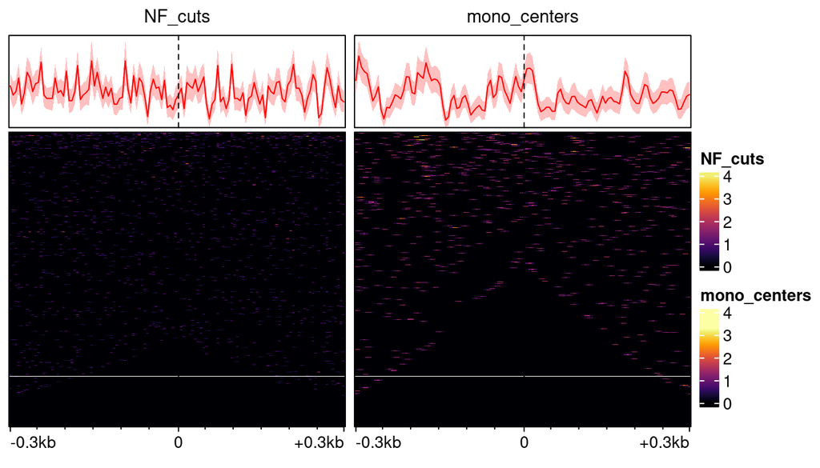

```r
# prepare track list
tracks <- c("NF_cuts" = "NF_cuts.bw", "mono_centers" = "mono_centers.bw")

# extract signals in a 600bp window (±300bp) around motif centers, at 5bp resolution
sm <- signal2Matrix(tracks, moi, w = 5, extend = 300)

# plot the signals
plotEnrichedHeatmaps(sm, trim=0.95, multiScale=TRUE, axis_name="0")
```

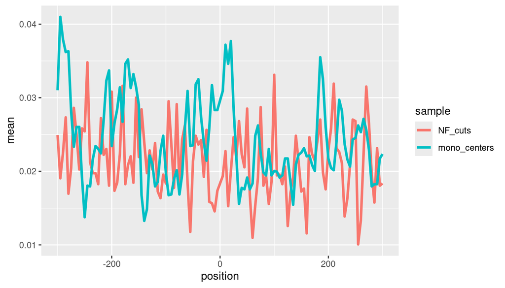

```r
# melt signals for ggplot overlay - To better visualize the relationship between signals, we can overlay them aggregated across regions:

d <- meltSignals(sm)

# overlay plot
ggplot(d, aes(position, mean, colour = sample)) +
  geom_line(linewidth = 1.2)
```

### Interpretation

There is no clear pattern. Both signals are noisy fluctuating around baseline with no enrichment or depletion at the center.

# Part 2: Differential motif accessibility between males and females

## Loading the peak counts data

```r
download.file("https://ethz-ins.org/content/mouse_mm38_hippocampus.peakCounts.SE.rds",
              "peakCounts.rds", mode = "wb")
```

```r
se <- readRDS("peakCounts.rds")
se
```

```
## class: RangedSummarizedExperiment
## dim: 20660 12
## metadata(0):
## assays(1): counts
## rownames: NULL
## rowData names(0):
## colnames(12): Control_female_GSM6041841.bam
##   Control_female_GSM6041842.bam ... FSS_male_GSM6041857.bam
##   FSS_male_GSM6041858.bam
## colData names(1): depth
```

## Preparing the object and annotating regions

Restricting to standard chromosomes, set the sequence level style to match the BSgenome object, and compute GC bias for each peak region.

```r
se <- GenomeInfoDb::keepStandardChromosomes(se, pruning.mode = "coarse")
seqlevelsStyle(se) <- "UCSC"
se <- addGCBias(se, genome = BSgenome.Mmusculus.UCSC.mm10)
```

## Scanning peaks for motif matches

```r
motifs <- query(MotifDb, "HOCOMOCOv13")
motifs <- do.call(TFBSTools::PWMatrixList,
                  convert_motifs(motifs, class = "TFBSTools-PWMatrix"))
names(motifs) <- make.unique(sapply(motifs, \(x) gsub("\\..+", "", x@name)))

matches <- motifmatchr::matchMotifs(motifs, se, genome = BSgenome.Mmusculus.UCSC.mm10)
```

## Computing motif deviation scores with betterChromVAR

`betterChromVAR` computes per-sample deviation z-scores for each motif, reflecting whether a motif’s associated regions are more or less accessible than expected given the GC content and overall accessibility.

```r
dev <- betterChromVAR(se, matches)
```

## Differential motif accessibility: males vs females

```r
# assign sex and condition based on sample naming convention
dev$sex <- ifelse(grepl("_male_", colnames(dev)), "Male", "Female")
dev$condition <- ifelse(grepl("FSS", colnames(dev)), "Stressed", "Control")

# set up the design matrix including both variables
design <- model.matrix(~condition + sex, data = as.data.frame(colData(dev)))

# fit linear model and compute moderated statistics
# the coefficient "sexMale" captures the sex effect while controlling for condition
fit <- eBayes(lmFit(assay(dev, "z"), design))
res <- as.data.frame(topTable(fit, coef = "sexMale", number = Inf))
res$motif <- row.names(res)

head(res)
```

```
##             logFC      AveExpr          t      P.Value    adj.P.Val        B
## TYY2.1  -2.051770  0.080020947 -11.366262 4.208549e-08 3.345701e-05 9.049313
## TYY2    -2.088264  0.128084256 -11.215638 4.927395e-08 3.345701e-05 8.903512
## TSHZ2   -2.332144  0.016454756 -10.766244 7.971673e-08 3.608511e-05 8.455965
## ZN140.1 -1.832413  0.093276393  -8.914301 6.977323e-07 2.266423e-04 6.392822
## ZN584   -1.510905 -0.002130256  -8.749158 8.605208e-07 2.266423e-04 6.190016
## ZFP42   -2.364730  0.029266640  -8.631190 1.001365e-06 2.266423e-04 6.043100
##           motif
## TYY2.1   TYY2.1
## TYY2       TYY2
## TSHZ2     TSHZ2
## ZN140.1 ZN140.1
## ZN584     ZN584
## ZFP42     ZFP42
```

## Volcano plot of differential motif accessibility

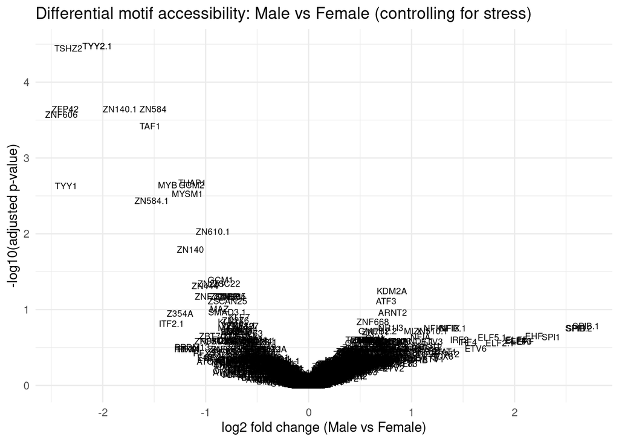

```r
ggplot(res, aes(logFC, -log10(adj.P.Val), label = motif)) +
  geom_text(size = 2.5) +
  labs(
    x = "log2 fold change (Male vs Female)",
    y = "-log10(adjusted p-value)",
    title = "Differential motif accessibility: Male vs Female (controlling for stress)"
  ) +
  theme_minimal()
```

## Heatmap of top candidate motifs

I visualise the deviation z-scores for the top differentially accessible motifs across all samples, grouped by sex and condition.

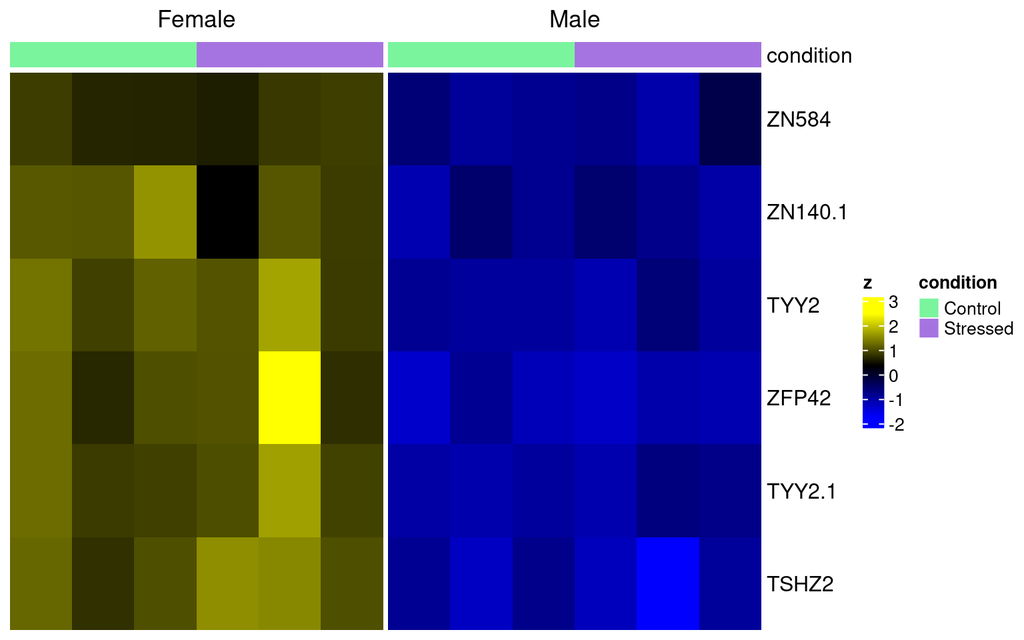

```r
top_motifs <- head(row.names(res), 6)
sechm(dev, top_motifs, gaps_at = "sex", assayName = "z")
```

### Interpretation

All six top motifs (TYY2.1, TYY2, TSHZ2, ZN140.1, ZN584, ZFP42) show negative log-fold changes, indicating higher accessibility in females than males. The heatmap confirms this: these motifs consistently have positive z-scores in female samples and negative z-scores in male samples, and this holds in both control and stressed conditions. This means the differences are driven by sex rather than by the stress treatment. Most of the top hits are zinc finger transcription factors.